# Project: Analysis of the Movie Dataset.

- Introduction
- Data Wrangling
- Exploratory Data Analysis
- Conclusions

## Introduction

This data set contains information of about 10,000 movies collected from The Movie Database (TMDb), including user ratings and revenue.

This data set has the following columns: id - This is the unique identifier of a movie  
imdb_id - This is the Imbd identifier  
popularity - This shows movies and their probability of discovery since with higher popularity it's boosted in the search results.  
budget - This shows the budget of the associated movie.  
revenue - This shows the revenue earned from the movie.  
original_title - This is the title of the movie.  
cast - This shows the main actors of the movie.  
homepage - This shows the website of the movie.  
director - Shows the director of the associated movie.  
tagline - This shows the major line for the associated movie.  
keywords - This shows the key words of the associated movie.  
overview - This shows the summary of the associated movie.  
runtime - Shows the number of minutes the associated movie runs for.  
genres - shows the genres of the associated movie  
production_companies - This shows the production companies involved.  
release_date - This shows the release date of the associated movie.  
vote_count - This shows the total vote count of the associated movie.  
vote_average - This shows the average vote count of the associated movie.  
release_year - This shows the release year of the associated movie.  
budget_adj - shows the budget of the associated movie in terms of 2010 dollars, accounting for inflation over time.  
revenue_adj - shows the revenue of the associated movie in terms of 2010 dollars, accounting for inflation over time.

Some of the questions we are investigating about the data set are:

1. Are the movies that are released more recently have more profit?
2. Does the voting average and vote count affect the popularity rating of a movie?

```python
#importing the packages to use in the investigation

import pandas as pd
import numpy as np
import matplotlib.pyplot as plt
import seaborn as sns
%matplotlib inline
```

## Data Wrangling

### General Properties

This is where I am doing the data wrangling of the movie dataset to find out what information I require for my analysis starting with loading and previewing.

I start by making a function for reading the dataset since it is a function I will want to use more.

```python
def data(arg):
    df=pd.read_csv(arg)
    return df
```

```python
df = data('tmdb-movies-Copy1.csv')
df.head()
```

|  | id | imdb_id | popularity | budget | revenue | original_title | cast | homepage | director | tagline | ... | overview | runtime | genres | production_companies | release_date | vote_count | vote_average | release_year | budget_adj | revenue_adj |
| --- | --- | --- | --- | --- | --- | --- | --- | --- | --- | --- | --- | --- | --- | --- | --- | --- | --- | --- | --- | --- | --- |
| 0 | 135397 | tt0369610 | 32.985763 | 150000000 | 1513528810 | Jurassic World | Chris Pratt\|Bryce Dallas Howard\|Irrfan Khan\|Vi... | http://www.jurassicworld.com/ | Colin Trevorrow | The park is open. | ... | Twenty-two years after the events of Jurassic ... | 124 | Action\|Adventure\|Science Fiction\|Thriller | Universal Studios\|Amblin Entertainment\|Legenda... | 6/9/15 | 5562 | 6.5 | 2015 | 1.379999e+08 | 1.392446e+09 |
| 1 | 76341 | tt1392190 | 28.419936 | 150000000 | 378436354 | Mad Max: Fury Road | Tom Hardy\|Charlize Theron\|Hugh Keays-Byrne\|Nic... | http://www.madmaxmovie.com/ | George Miller | What a Lovely Day. | ... | An apocalyptic story set in the furthest reach... | 120 | Action\|Adventure\|Science Fiction\|Thriller | Village Roadshow Pictures\|Kennedy Miller Produ... | 5/13/15 | 6185 | 7.1 | 2015 | 1.379999e+08 | 3.481613e+08 |
| 2 | 262500 | tt2908446 | 13.112507 | 110000000 | 295238201 | Insurgent | Shailene Woodley\|Theo James\|Kate Winslet\|Ansel... | http://www.thedivergentseries.movie/#insurgent | Robert Schwentke | One Choice Can Destroy You | ... | Beatrice Prior must confront her inner demons ... | 119 | Adventure\|Science Fiction\|Thriller | Summit Entertainment\|Mandeville Films\|Red Wago... | 3/18/15 | 2480 | 6.3 | 2015 | 1.012000e+08 | 2.716190e+08 |
| 3 | 140607 | tt2488496 | 11.173104 | 200000000 | 2068178225 | Star Wars: The Force Awakens | Harrison Ford\|Mark Hamill\|Carrie Fisher\|Adam D... | http://www.starwars.com/films/star-wars-episod... | J.J. Abrams | Every generation has a story. | ... | Thirty years after defeating the Galactic Empi... | 136 | Action\|Adventure\|Science Fiction\|Fantasy | Lucasfilm\|Truenorth Productions\|Bad Robot | 12/15/15 | 5292 | 7.5 | 2015 | 1.839999e+08 | 1.902723e+09 |
| 4 | 168259 | tt2820852 | 9.335014 | 190000000 | 1506249360 | Furious 7 | Vin Diesel\|Paul Walker\|Jason Statham\|Michelle ... | http://www.furious7.com/ | James Wan | Vengeance Hits Home | ... | Deckard Shaw seeks revenge against Dominic Tor... | 137 | Action\|Crime\|Thriller | Universal Pictures\|Original Film\|Media Rights ... | 4/1/15 | 2947 | 7.3 | 2015 | 1.747999e+08 | 1.385749e+09 |

5 rows × 21 columns

I also want to know the number of rows and columns in the data set to get the size of the data frame.

```python
df.shape
```

```
(10866, 21)
```

To get an overview of the columns and the information they contain.

```python
df.info()
```

```
<class 'pandas.core.frame.DataFrame'>
RangeIndex: 10866 entries, 0 to 10865
Data columns (total 21 columns):
 #   Column                Non-Null Count  Dtype
---  ------                --------------  -----
 0   id                    10866 non-null  int64
 1   imdb_id               10856 non-null  object
 2   popularity            10866 non-null  float64
 3   budget                10866 non-null  int64
 4   revenue               10866 non-null  int64
 5   original_title        10866 non-null  object
 6   cast                  10790 non-null  object
 7   homepage              2936 non-null   object
 8   director              10822 non-null  object
 9   tagline               8042 non-null   object
 10  keywords              9373 non-null   object
 11  overview              10862 non-null  object
 12  runtime               10866 non-null  int64
 13  genres                10843 non-null  object
 14  production_companies  9836 non-null   object
 15  release_date          10866 non-null  object
 16  vote_count            10866 non-null  int64
 17  vote_average          10866 non-null  float64
 18  release_year          10866 non-null  int64
 19  budget_adj            10866 non-null  float64
 20  revenue_adj           10866 non-null  float64
dtypes: float64(4), int64(6), object(11)
memory usage: 1.7+ MB
```

To get some summary statistics of the data frame.

```python
df.describe()
```

|  | id | popularity | budget | revenue | runtime | vote_count | vote_average | release_year | budget_adj | revenue_adj |
| --- | --- | --- | --- | --- | --- | --- | --- | --- | --- | --- |
| count | 10866.000000 | 10866.000000 | 1.086600e+04 | 1.086600e+04 | 10866.000000 | 10866.000000 | 10866.000000 | 10866.000000 | 1.086600e+04 | 1.086600e+04 |
| mean | 66064.177434 | 0.646441 | 1.462570e+07 | 3.982332e+07 | 102.070863 | 217.389748 | 5.974922 | 2001.322658 | 1.755104e+07 | 5.136436e+07 |
| std | 92130.136561 | 1.000185 | 3.091321e+07 | 1.170035e+08 | 31.381405 | 575.619058 | 0.935142 | 12.812941 | 3.430616e+07 | 1.446325e+08 |
| min | 5.000000 | 0.000065 | 0.000000e+00 | 0.000000e+00 | 0.000000 | 10.000000 | 1.500000 | 1960.000000 | 0.000000e+00 | 0.000000e+00 |
| 25% | 10596.250000 | 0.207583 | 0.000000e+00 | 0.000000e+00 | 90.000000 | 17.000000 | 5.400000 | 1995.000000 | 0.000000e+00 | 0.000000e+00 |
| 50% | 20669.000000 | 0.383856 | 0.000000e+00 | 0.000000e+00 | 99.000000 | 38.000000 | 6.000000 | 2006.000000 | 0.000000e+00 | 0.000000e+00 |
| 75% | 75610.000000 | 0.713817 | 1.500000e+07 | 2.400000e+07 | 111.000000 | 145.750000 | 6.600000 | 2011.000000 | 2.085325e+07 | 3.369710e+07 |
| max | 417859.000000 | 32.985763 | 4.250000e+08 | 2.781506e+09 | 900.000000 | 9767.000000 | 9.200000 | 2015.000000 | 4.250000e+08 | 2.827124e+09 |

From the summary statistics above, we can see the averages of the different movies and see the classifications in the different movies. This shows some key information like 50% of the dataset have revenues and budgets of 0 which needs to be investigated further. There are also maximum amounts of the different fields with one of the movies having a runtime of 900 minutes which can be further investigated.

### Data Cleaning

So we look at the columns present and which ones I need the most.

```python
df.info()
```

```
<class 'pandas.core.frame.DataFrame'>
RangeIndex: 10866 entries, 0 to 10865
Data columns (total 21 columns):
 #   Column                Non-Null Count  Dtype
---  ------                --------------  -----
 0   id                    10866 non-null  int64
 1   imdb_id               10856 non-null  object
 2   popularity            10866 non-null  float64
 3   budget                10866 non-null  int64
 4   revenue               10866 non-null  int64
 5   original_title        10866 non-null  object
 6   cast                  10790 non-null  object
 7   homepage              2936 non-null   object
 8   director              10822 non-null  object
 9   tagline               8042 non-null   object
 10  keywords              9373 non-null   object
 11  overview              10862 non-null  object
 12  runtime               10866 non-null  int64
 13  genres                10843 non-null  object
 14  production_companies  9836 non-null   object
 15  release_date          10866 non-null  object
 16  vote_count            10866 non-null  int64
 17  vote_average          10866 non-null  float64
 18  release_year          10866 non-null  int64
 19  budget_adj            10866 non-null  float64
 20  revenue_adj           10866 non-null  float64
dtypes: float64(4), int64(6), object(11)
memory usage: 1.7+ MB
```

Now I need to drop the columns I will not use in the analysis based on the assesment above.

```python
df.drop(['imdb_id', 'cast', 'homepage', 'tagline', 'keywords', 'overview', 'production_companies', 'genres'], axis = 1, inplace = True)
df.head()
```

|  | id | popularity | budget | revenue | original_title | director | runtime | release_date | vote_count | vote_average | release_year | budget_adj | revenue_adj |
| --- | --- | --- | --- | --- | --- | --- | --- | --- | --- | --- | --- | --- | --- |
| 0 | 135397 | 32.985763 | 150000000 | 1513528810 | Jurassic World | Colin Trevorrow | 124 | 6/9/15 | 5562 | 6.5 | 2015 | 1.379999e+08 | 1.392446e+09 |
| 1 | 76341 | 28.419936 | 150000000 | 378436354 | Mad Max: Fury Road | George Miller | 120 | 5/13/15 | 6185 | 7.1 | 2015 | 1.379999e+08 | 3.481613e+08 |
| 2 | 262500 | 13.112507 | 110000000 | 295238201 | Insurgent | Robert Schwentke | 119 | 3/18/15 | 2480 | 6.3 | 2015 | 1.012000e+08 | 2.716190e+08 |
| 3 | 140607 | 11.173104 | 200000000 | 2068178225 | Star Wars: The Force Awakens | J.J. Abrams | 136 | 12/15/15 | 5292 | 7.5 | 2015 | 1.839999e+08 | 1.902723e+09 |
| 4 | 168259 | 9.335014 | 190000000 | 1506249360 | Furious 7 | James Wan | 137 | 4/1/15 | 2947 | 7.3 | 2015 | 1.747999e+08 | 1.385749e+09 |

Then we look at the distribution of the dataframe.

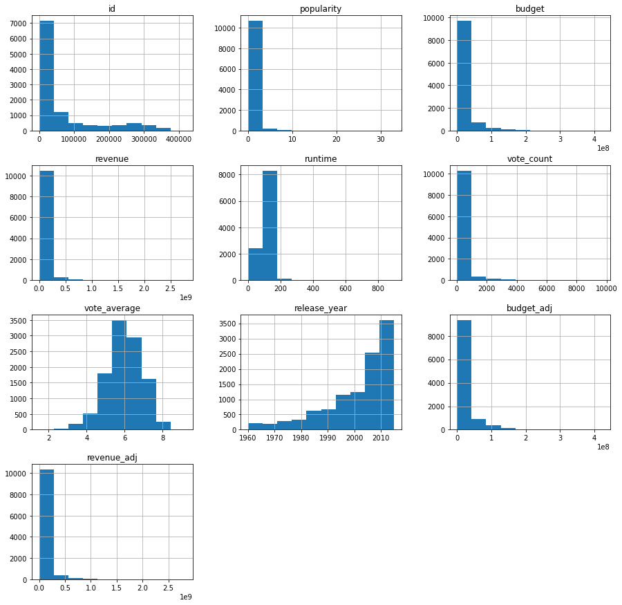

```python
df.hist(figsize = (15,15));
```

As you can see, most of the data is skewed to the right meaning most data points are less than the mean of the data frame.

Therefore, I wanted to check the information at the bottom of the data frame.

```python
df.tail()
```

|  | id | popularity | budget | revenue | original_title | director | runtime | release_date | vote_count | vote_average | release_year | budget_adj | revenue_adj |
| --- | --- | --- | --- | --- | --- | --- | --- | --- | --- | --- | --- | --- | --- |
| 10861 | 21 | 0.080598 | 0 | 0 | The Endless Summer | Bruce Brown | 95 | 6/15/66 | 11 | 7.4 | 1966 | 0.000000 | 0.0 |
| 10862 | 20379 | 0.065543 | 0 | 0 | Grand Prix | John Frankenheimer | 176 | 12/21/66 | 20 | 5.7 | 1966 | 0.000000 | 0.0 |
| 10863 | 39768 | 0.065141 | 0 | 0 | Beregis Avtomobilya | Eldar Ryazanov | 94 | 1/1/66 | 11 | 6.5 | 1966 | 0.000000 | 0.0 |
| 10864 | 21449 | 0.064317 | 0 | 0 | What's Up, Tiger Lily? | Woody Allen | 80 | 11/2/66 | 22 | 5.4 | 1966 | 0.000000 | 0.0 |
| 10865 | 22293 | 0.035919 | 19000 | 0 | Manos: The Hands of Fate | Harold P. Warren | 74 | 11/15/66 | 15 | 1.5 | 1966 | 127642.279154 | 0.0 |

Then we look at the missing values in the data frame remaining.

```python
df.isnull().sum()
```

```
id                 0
popularity         0
budget             0
revenue            0
original_title     0
director          44
runtime            0
release_date       0
vote_count         0
vote_average       0
release_year       0
budget_adj         0
revenue_adj        0
dtype: int64
```

The director column has a few missing values of which I can investigate further on which films had No Director indicated.

```python
df["director"].fillna("No Director", inplace = True)
```

```python
df_nodirector = df.query('director == "No Director"')
df_nodirector
```

|  | id | popularity | budget | revenue | original_title | director | runtime | release_date | vote_count | vote_average | release_year | budget_adj | revenue_adj |
| --- | --- | --- | --- | --- | --- | --- | --- | --- | --- | --- | --- | --- | --- |
| 532 | 320996 | 0.126594 | 0 | 0 | Iliza Shlesinger: Freezing Hot | No Director | 71 | 1/23/15 | 14 | 6.6 | 2015 | 0.000000e+00 | 0.000000e+00 |
| 548 | 355131 | 0.108072 | 0 | 0 | Sense8: Creating the World | No Director | 25 | 8/10/15 | 12 | 7.5 | 2015 | 0.000000e+00 | 0.000000e+00 |
| 556 | 321160 | 0.100910 | 0 | 0 | With This Ring | No Director | 105 | 1/24/15 | 14 | 6.5 | 2015 | 0.000000e+00 | 0.000000e+00 |
| 1032 | 259910 | 0.291253 | 0 | 0 | Marvel Studios: Assembling a Universe | No Director | 43 | 3/18/14 | 32 | 6.3 | 2014 | 0.000000e+00 | 0.000000e+00 |
| 1054 | 253675 | 0.269468 | 0 | 0 | Unlocking Sherlock | No Director | 60 | 1/19/14 | 11 | 7.2 | 2014 | 0.000000e+00 | 0.000000e+00 |
| 1203 | 256561 | 0.119891 | 150000 | 0 | Free to Play | No Director | 75 | 3/19/14 | 40 | 7.0 | 2014 | 1.381637e+05 | 0.000000e+00 |
| 1241 | 296370 | 0.135376 | 0 | 0 | Dance-Off | No Director | 0 | 1/1/14 | 18 | 5.7 | 2014 | 0.000000e+00 | 0.000000e+00 |
| 1288 | 301235 | 0.038364 | 0 | 0 | Top Gear: The Perfect Road Trip 2 | No Director | 94 | 11/17/14 | 12 | 6.8 | 2014 | 0.000000e+00 | 0.000000e+00 |
| 1852 | 133365 | 0.256703 | 0 | 0 | The Diary of Anne Frank | No Director | 100 | 1/9/09 | 19 | 7.5 | 2009 | 0.000000e+00 | 0.000000e+00 |
| 1872 | 26379 | 0.091395 | 3250000 | 0 | Paa | No Director | 133 | 12/4/09 | 11 | 6.1 | 2009 | 3.303301e+06 | 0.000000e+00 |
| 1895 | 281979 | 0.056777 | 0 | 0 | Doctor Who: The Waters of Mars | No Director | 62 | 12/19/09 | 25 | 8.0 | 2009 | 0.000000e+00 | 0.000000e+00 |
| 2221 | 48832 | 0.281852 | 0 | 0 | Scott Pilgrim vs. the Animation | No Director | 4 | 8/10/10 | 19 | 7.7 | 2010 | 0.000000e+00 | 0.000000e+00 |
| 2286 | 47911 | 0.207234 | 0 | 0 | Bo Burnham: Words, Words, Words | No Director | 63 | 10/19/10 | 13 | 6.5 | 2010 | 0.000000e+00 | 0.000000e+00 |
| 2290 | 51823 | 0.203502 | 0 | 0 | Across the Line: The Exodus of Charlie Wright | No Director | 94 | 12/28/10 | 11 | 6.0 | 2010 | 0.000000e+00 | 0.000000e+00 |
| 2315 | 48373 | 0.171615 | 0 | 0 | Listen to Your Heart | No Director | 0 | 8/14/10 | 29 | 7.3 | 2010 | 0.000000e+00 | 0.000000e+00 |
| 2318 | 34134 | 0.170408 | 0 | 0 | Barbie in A Mermaid Tale | No Director | 75 | 1/26/10 | 35 | 6.3 | 2010 | 0.000000e+00 | 0.000000e+00 |
| 2376 | 315620 | 0.068411 | 0 | 0 | Doctor Who: A Christmas Carol | No Director | 62 | 12/25/10 | 11 | 7.7 | 2010 | 0.000000e+00 | 0.000000e+00 |
| 2397 | 241829 | 0.033048 | 0 | 0 | The Making of The Walking Dead | No Director | 30 | 7/31/10 | 42 | 8.4 | 2010 | 0.000000e+00 | 0.000000e+00 |
| 2401 | 45644 | 0.067753 | 0 | 0 | Opeth: In Live Concert At The Royal Albert Hall | No Director | 163 | 9/21/10 | 10 | 8.6 | 2010 | 0.000000e+00 | 0.000000e+00 |
| 2403 | 72013 | 0.067620 | 0 | 0 | Yu-Gi-Oh! 3D: Bonds Beyond Time | No Director | 60 | 1/23/10 | 10 | 6.0 | 2010 | 0.000000e+00 | 0.000000e+00 |
| 3171 | 17171 | 0.019819 | 0 | 0 | The Assassination of Jesse James: Death Of An ... | No Director | 32 | 1/1/08 | 20 | 6.8 | 2008 | 0.000000e+00 | 0.000000e+00 |
| 3224 | 20313 | 0.224721 | 0 | 0 | John Mayer: Where the Light Is Live in Los Ang... | No Director | 164 | 7/1/08 | 16 | 8.5 | 2008 | 0.000000e+00 | 0.000000e+00 |
| 3276 | 15467 | 0.147657 | 4180000 | 11000000 | Kismat Konnection | No Director | 153 | 7/18/08 | 11 | 5.8 | 2008 | 4.233448e+06 | 1.114065e+07 |
| 3285 | 36131 | 0.136883 | 0 | 0 | Tropic Thunder: Rain of Madness | No Director | 30 | 8/26/08 | 12 | 6.9 | 2008 | 0.000000e+00 | 0.000000e+00 |
| 3357 | 32836 | 0.042517 | 0 | 0 | Bill Burr: Why Do I Do This? | No Director | 55 | 9/23/08 | 10 | 8.0 | 2008 | 0.000000e+00 | 0.000000e+00 |
| 3365 | 22258 | 0.002475 | 0 | 0 | Foo Fighters: Live at Wembley Stadium | No Director | 120 | 8/25/08 | 10 | 8.4 | 2008 | 0.000000e+00 | 0.000000e+00 |
| 3369 | 77974 | 0.001682 | 0 | 0 | Wizards On Deck With Hannah Montana | No Director | 68 | 2/11/08 | 14 | 6.1 | 2008 | 0.000000e+00 | 0.000000e+00 |
| 3910 | 79976 | 0.002006 | 0 | 0 | Steve Jobs: One Last Thing | No Director | 60 | 11/2/11 | 11 | 6.6 | 2011 | 0.000000e+00 | 0.000000e+00 |
| 4679 | 91342 | 0.421746 | 0 | 0 | Barbie in A Mermaid Tale 2 | No Director | 74 | 2/23/12 | 22 | 6.0 | 2012 | 0.000000e+00 | 0.000000e+00 |
| 4797 | 369145 | 0.167501 | 0 | 0 | Doctor Who: The Snowmen | No Director | 60 | 12/25/12 | 10 | 7.8 | 2012 | 0.000000e+00 | 0.000000e+00 |
| 4872 | 269177 | 0.090552 | 0 | 0 | Party Bercy | No Director | 120 | 9/23/12 | 15 | 6.4 | 2012 | 0.000000e+00 | 0.000000e+00 |
| 4939 | 168219 | 0.003183 | 0 | 0 | The Men Who Built America | No Director | 360 | 10/16/12 | 11 | 5.3 | 2012 | 0.000000e+00 | 0.000000e+00 |
| 5413 | 20378 | 0.324270 | 0 | 0 | The Brave Little Toaster to the Rescue | No Director | 74 | 11/1/97 | 11 | 7.0 | 1997 | 0.000000e+00 | 0.000000e+00 |
| 5866 | 246569 | 0.211825 | 5000000 | 0 | Jinxed | No Director | 75 | 11/29/13 | 19 | 7.0 | 2013 | 4.680167e+06 | 0.000000e+00 |
| 5915 | 284019 | 0.168210 | 0 | 0 | Phineas and Ferb: Mission Marvel | No Director | 44 | 8/16/13 | 13 | 5.9 | 2013 | 0.000000e+00 | 0.000000e+00 |
| 5972 | 238234 | 0.165605 | 0 | 0 | Top Gear: The Perfect Road Trip | No Director | 84 | 11/17/13 | 35 | 7.6 | 2013 | 0.000000e+00 | 0.000000e+00 |
| 6033 | 238185 | 0.048587 | 0 | 0 | Russell Brand: Messiah Complex | No Director | 99 | 11/25/13 | 12 | 6.8 | 2013 | 0.000000e+00 | 0.000000e+00 |
| 6181 | 18729 | 0.000065 | 0 | 0 | North and South, Book I | No Director | 561 | 11/3/85 | 17 | 6.0 | 1985 | 0.000000e+00 | 0.000000e+00 |
| 7579 | 58432 | 0.443952 | 0 | 0 | La hora frÃa | No Director | 92 | 9/14/07 | 10 | 4.9 | 2007 | 0.000000e+00 | 0.000000e+00 |
| 7767 | 282758 | 0.126603 | 0 | 0 | Doctor Who: The Runaway Bride | No Director | 60 | 7/6/07 | 18 | 7.6 | 2007 | 0.000000e+00 | 0.000000e+00 |
| 7814 | 25565 | 0.040311 | 0 | 0 | Transformers: Beginnings | No Director | 22 | 10/16/07 | 34 | 5.8 | 2007 | 0.000000e+00 | 0.000000e+00 |
| 9593 | 46188 | 0.001662 | 0 | 0 | Peter Pan | No Director | 52 | 1/1/88 | 28 | 6.6 | 1988 | 0.000000e+00 | 0.000000e+00 |
| 10386 | 225804 | 0.118854 | 0 | 0 | The Making of 'The Nightmare Before Christmas' | No Director | 25 | 10/3/93 | 15 | 7.5 | 1993 | 0.000000e+00 | 0.000000e+00 |
| 10426 | 34038 | 0.114034 | 0 | 0 | Magical Mystery Tour | No Director | 55 | 12/25/67 | 15 | 5.8 | 1967 | 0.000000e+00 | 0.000000e+00 |

Now I can get the distribution of this data to see how it can affect my analysis.

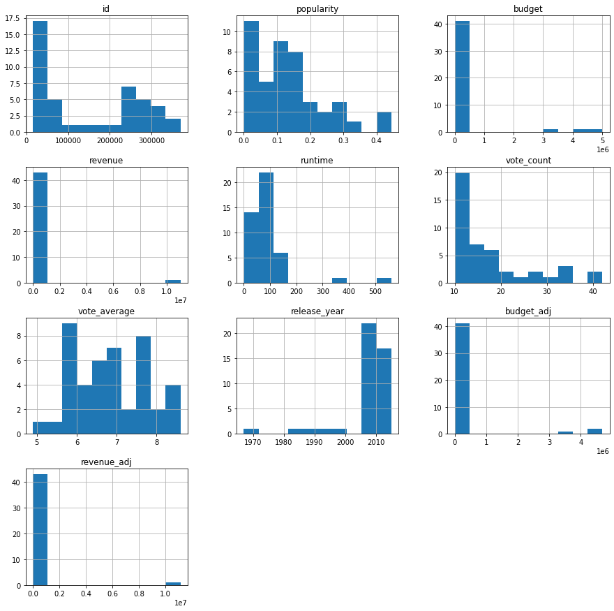

```python
df_nodirector.hist(figsize = (15,15));
```

```python
df.dropna(inplace = True)
```

To check if any columns have null values now.

```python
df.isnull().sum().any()
```

```
False
```

```python
df.info()
```

```
<class 'pandas.core.frame.DataFrame'>
RangeIndex: 10866 entries, 0 to 10865
Data columns (total 13 columns):
 #   Column          Non-Null Count  Dtype
---  ------          --------------  -----
 0   id              10866 non-null  int64
 1   popularity      10866 non-null  float64
 2   budget          10866 non-null  int64
 3   revenue         10866 non-null  int64
 4   original_title  10866 non-null  object
 5   director        10866 non-null  object
 6   runtime         10866 non-null  int64
 7   release_date    10866 non-null  object
 8   vote_count      10866 non-null  int64
 9   vote_average    10866 non-null  float64
 10  release_year    10866 non-null  int64
 11  budget_adj      10866 non-null  float64
 12  revenue_adj     10866 non-null  float64
dtypes: float64(4), int64(6), object(3)
memory usage: 1.1+ MB
```

The output above shows that there are no more null values and we can now explore the data frame.

```python
df.duplicated().sum()
```

```
1
```

With one duplicated value, this does not affect the result of our analysis, therefore, this data will remain in our dataframe.

## Exploratory Data Analysis

### Are the movies that are released more recently have more profit?

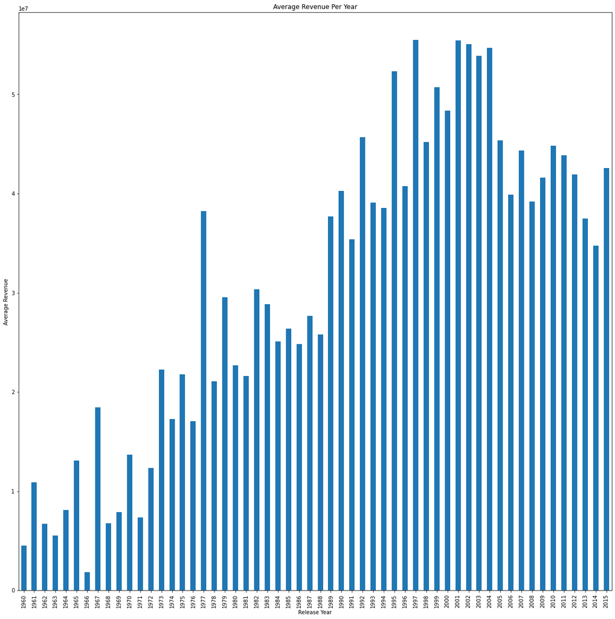

```python
df.groupby('release_year').revenue.mean().plot(kind = 'bar', figsize = (20,20), title = ('Average Revenue Per Year'), xlabel = ('Release Year'), ylabel = ('Average Revenue'));
```

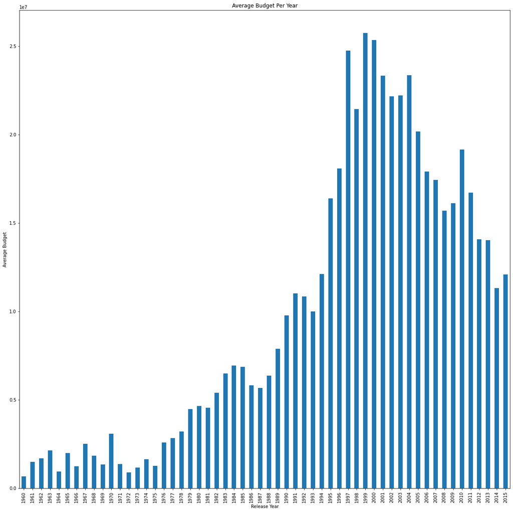

```python
df.groupby('release_year').budget.mean().plot(kind = 'bar', figsize = (20,20), title = ('Average Budget Per Year'), xlabel = ('Release Year'), ylabel = ('Average Budget'));
```

The bar graphs above show the yearly average of both the budget and revenue done by the movies. We can see a gradual increase in both graphs as the years move and in the 90s, both peak meaning this period had a lot of investment and returns. Therefore we now need to see if there was any profit made and how it behaves year on year.

```python
df_revenue = df.groupby('release_year').revenue.mean()
df_budget  = df.groupby('release_year').budget.mean()
```

```python
df_profit = df_revenue - df_budget
df_profit
```

```
release_year
1960    3.842127e+06
1961    9.405909e+06
1962    5.026804e+06
1963    3.355103e+06
1964    7.178539e+06
1965    1.108219e+07
1966    5.909106e+05
1967    1.592956e+07
1968    4.943435e+06
1969    6.510580e+06
1970    1.056720e+07
1971    5.980247e+06
1972    1.146127e+07
1973    2.106891e+07
```

[output cut: 43 more lines]

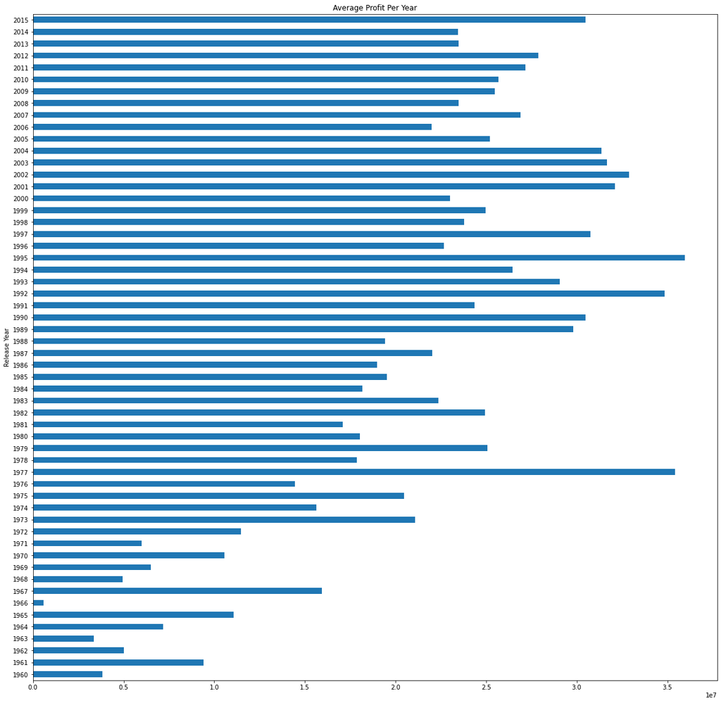

```python
df_profit.plot(kind = 'barh', figsize = (20,20), title = ('Average Profit Per Year'), xlabel = ('Release Year'), ylabel = ('Average Profit'));
```

The profit bar chart shows that the profit is fluctuating year on year and had peaks in 1977 and 1995 at around 35 million. This graph shows that the year does not affect the amount of profit as it fluctuates year on year. Now we want to see if the adjusted amounts of budget and revenue has similar movement.

```python
df_revenue_adj = df.groupby('release_year').revenue_adj.mean()
df_budget_adj  = df.groupby('release_year').budget_adj.mean()
```

```python
df_profit_adj = df_revenue_adj - df_budget_adj
df_profit_adj
```

```
release_year
1960    2.832787e+07
1961    6.861480e+07
1962    3.623546e+07
1963    2.388893e+07
1964    5.046705e+07
1965    7.669502e+07
1966    3.969746e+06
1967    1.041278e+08
1968    3.099022e+07
1969    3.870061e+07
1970    5.934926e+07
1971    3.220480e+07
1972    5.976551e+07
1973    1.034728e+08
```

[output cut: 43 more lines]

Now we compare the actual profit against the adjusted profit to know the difference between the two variables and how they affect the profit year on year.

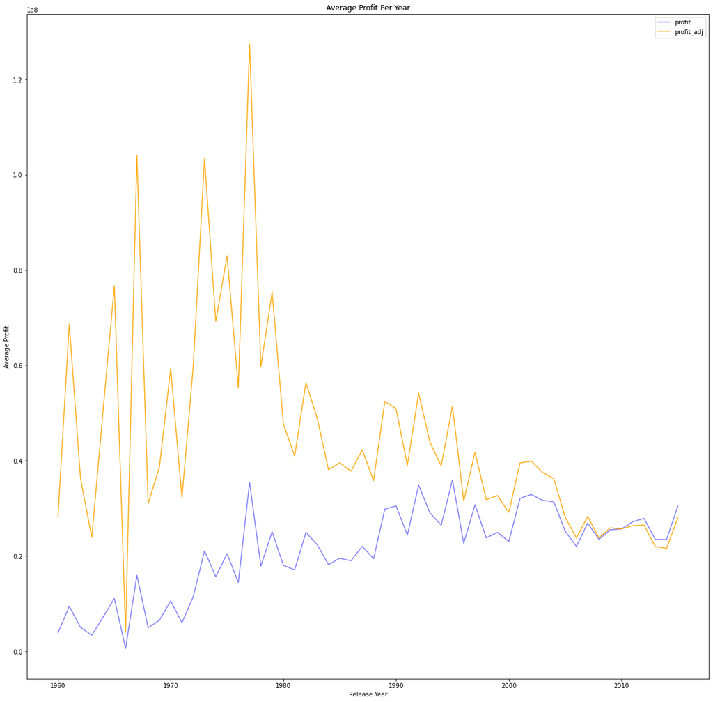

```python
df_profit.plot(kind='line',alpha=0.5, color= 'blue', label='profit', figsize = (20,20), title = ('Average Profit Per Year'), xlabel = ('Release Year'), ylabel = ('Average Profit'))
df_profit_adj.plot(kind='line',alpha=0.9, color= 'orange', label='profit_adj', figsize = (20,20), title = ('Average Profit Per Year'), xlabel = ('Release Year'), ylabel = ('Average Profit'))
plt.legend();
```

The line chart shows the comparison of the actual profit against the adjusted profit over the years. This shows the adjusted profit is higher than the actual until 2010 where the actual becomes a bit higher. This shows the effect of inflation on the different profits over the years.

### Does the voting average and vote count affect the popularity rating of a movie?

Here we would like to see how the voting average and vote count influence the popularity of a movie where we start by viewing the data which we will be analysing.

```python
df.describe()
```

|  | id | popularity | budget | revenue | runtime | vote_count | vote_average | release_year | budget_adj | revenue_adj |
| --- | --- | --- | --- | --- | --- | --- | --- | --- | --- | --- |
| count | 10866.000000 | 10866.000000 | 1.086600e+04 | 1.086600e+04 | 10866.000000 | 10866.000000 | 10866.000000 | 10866.000000 | 1.086600e+04 | 1.086600e+04 |
| mean | 66064.177434 | 0.646441 | 1.462570e+07 | 3.982332e+07 | 102.070863 | 217.389748 | 5.974922 | 2001.322658 | 1.755104e+07 | 5.136436e+07 |
| std | 92130.136561 | 1.000185 | 3.091321e+07 | 1.170035e+08 | 31.381405 | 575.619058 | 0.935142 | 12.812941 | 3.430616e+07 | 1.446325e+08 |
| min | 5.000000 | 0.000065 | 0.000000e+00 | 0.000000e+00 | 0.000000 | 10.000000 | 1.500000 | 1960.000000 | 0.000000e+00 | 0.000000e+00 |
| 25% | 10596.250000 | 0.207583 | 0.000000e+00 | 0.000000e+00 | 90.000000 | 17.000000 | 5.400000 | 1995.000000 | 0.000000e+00 | 0.000000e+00 |
| 50% | 20669.000000 | 0.383856 | 0.000000e+00 | 0.000000e+00 | 99.000000 | 38.000000 | 6.000000 | 2006.000000 | 0.000000e+00 | 0.000000e+00 |
| 75% | 75610.000000 | 0.713817 | 1.500000e+07 | 2.400000e+07 | 111.000000 | 145.750000 | 6.600000 | 2011.000000 | 2.085325e+07 | 3.369710e+07 |
| max | 417859.000000 | 32.985763 | 4.250000e+08 | 2.781506e+09 | 900.000000 | 9767.000000 | 9.200000 | 2015.000000 | 4.250000e+08 | 2.827124e+09 |

I start by looking at the correlation of the popularity with both the voting average and the voting count.

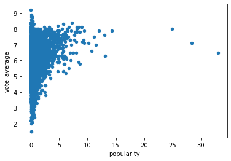

```python
df.plot(x = 'popularity', y = 'vote_average', kind = 'scatter');
```

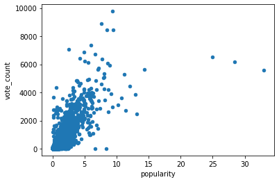

```python
df.plot(x = 'popularity', y = 'vote_count', kind = 'scatter');
```

```python
df_movies = df.groupby('original_title').popularity.mean()
df_movies.describe()
```

```
count    10571.000000
mean         0.642608
std          0.993856
min          0.000065
25%          0.208402
50%          0.384309
75%          0.710147
max         32.985763
Name: popularity, dtype: float64
```

We then look for the top most movie in terms of popularity and look at how the voting average and vote count match on it.

```python
df_movie = df.query('popularity > 32')
df_movie
```

|  | id | popularity | budget | revenue | original_title | director | runtime | release_date | vote_count | vote_average | release_year | budget_adj | revenue_adj |
| --- | --- | --- | --- | --- | --- | --- | --- | --- | --- | --- | --- | --- | --- |
| 0 | 135397 | 32.985763 | 150000000 | 1513528810 | Jurassic World | Colin Trevorrow | 124 | 6/9/15 | 5562 | 6.5 | 2015 | 1.379999e+08 | 1.392446e+09 |

This shows that Jurrasic World has the highest popularity index but the vote count (highest is 9767) and vote average (highest is 9.2) are not as high. So we look at the five movies that had the highest vote average against the highest vote count.

Below we are having the 5 movies with the highest voting averages and we plot them against their popularity.

```python
df_m = df.groupby('original_title').vote_average.max()
df_m.describe()
```

```
count    10571.000000
mean         5.986756
std          0.935537
min          1.500000
25%          5.400000
50%          6.000000
75%          6.600000
max          9.200000
Name: vote_average, dtype: float64
```

[output not shown]

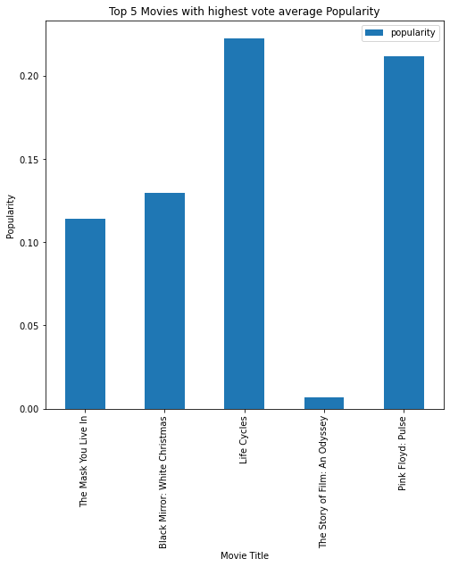

```python
df_topmovies = df.query('vote_average > 8.6')
df_topmovies.plot(x = 'original_title', y = 'popularity', kind = 'bar', figsize = (8,8), title = 'Top 5 Movies with highest vote average Popularity', xlabel = 'Movie Title', ylabel = 'Popularity');
df_topdirectors
```

The bar graph above shows the 5 highest movies in terms of voting average have popularity ratings that are mostly in the lower quartile. This shows that the correlation between the two is weak and closer to no correlation between the two. Therefore we go to having the 5 movies with the highest voting counts and we plot them against their popularity below.

```python
df_m2 = df.groupby('original_title').vote_count.max()
df_m2.describe()
```

```
count    10571.000000
mean       221.524170
std        582.485225
min         10.000000
25%         17.000000
50%         39.000000
75%        151.000000
max       9767.000000
Name: vote_count, dtype: float64
```

[output not shown]

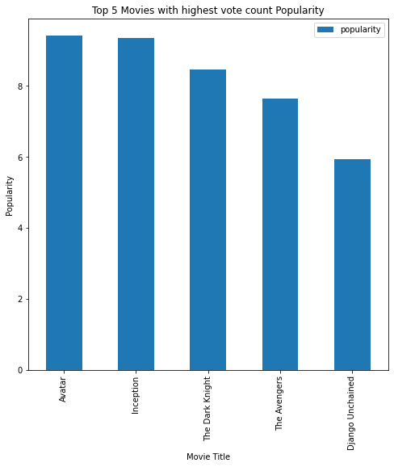

```python
df_top5movies = df.query('vote_count > 7200')
df_top5movies.plot(x = 'original_title', y = 'popularity', kind = 'bar', figsize = (8,8), title = 'Top 5 Movies with highest vote count Popularity', xlabel = 'Movie Title', ylabel = 'Popularity')
df_top15directors
```

The bar graph above shows the 5 highest movies in terms of voting count have popularity ratings that are mostly in the upper quartile. This shows that the correlation between the two is stronger between the two than the voting average.

We can also see that the top 5 movies are not similar in the two parameters showing that the vote count and vote average do not have a clear correlation from the findings.

## Conclusions

#### Limitations

I also did not perform statistical tests on the data frame provided.

I also left the duplicated value in the data frame.

#### Conclusion 1

From the first question, Are the movies that are released more recently have more profit? We were able to find out that the profit gradually increased upto certain years but it had a lot of fluctuations over the years and it wasn't a clear gradual increase of movie profits over the years.

We can also the adjusted profit is way higher in the years before 2010 showing that with inflation the value of profit is affected over the years.

#### Conclusion 2

From the second quetion, Does the voting average and vote count affect the popularity rating of a movie? We found out that the two parameters (voting average and vote count) have a weak correlation with the popularity but for the vote count there is a stronger correlation than voting average since most of the vote count were in the upper quartile of the popularity rating. We can also see that the top 5 movies are not similar in the two parameters showing that the vote count and vote average do not have a clear correlation from the findings.